# Part I - Project - Ford GoBike System Data

## Introduction

> The data consists of information regarding the rides taken in February, 2019, within the Ford GoBike System of the greater San Francisco Bay area. The data contains attributes, including details such as duration, start and end times, station locations, user type, and demographic information of the trips.

## Preliminary Wrangling

```python
# import all packages and set plots to be embedded inline
import numpy as np
import pandas as pd
import matplotlib.pyplot as plt
import seaborn as sb

%matplotlib inline
```

> Load in your dataset and describe its properties through the questions below. Try and motivate your exploration goals through this section.

```python
biketrips = pd.read_csv('201902-fordgobike-tripdata.csv')
```

```python
# Overview of the dataframe
print(biketrips.shape)
print(biketrips.info())
print(biketrips.head())
```

```
(183412, 16)
<class 'pandas.core.frame.DataFrame'>
RangeIndex: 183412 entries, 0 to 183411
Data columns (total 16 columns):
 #   Column                   Non-Null Count   Dtype
---  ------                   --------------   -----
 0   duration_sec             183412 non-null  int64
 1   start_time               183412 non-null  object
 2   end_time                 183412 non-null  object
 3   start_station_id         183215 non-null  float64
 4   start_station_name       183215 non-null  object
 5   start_station_latitude   183412 non-null  float64
 6   start_station_longitude  183412 non-null  float64
 7   end_station_id           183215 non-null  float64
 8   end_station_name         183215 non-null  object
 9   end_station_latitude     183412 non-null  float64
 10  end_station_longitude    183412 non-null  float64
 11  bike_id                  183412 non-null  int64
 12  user_type                183412 non-null  object
 13  member_birth_year        175147 non-null  float64
 14  member_gender            175147 non-null  object
 15  bike_share_for_all_trip  183412 non-null  object
dtypes: float64(7), int64(2), object(7)
memory usage: 22.4+ MB
None
   duration_sec                start_time                  end_time  \
0         52185  2019-02-28 17:32:10.1450  2019-03-01 08:01:55.9750
1         42521  2019-02-28 18:53:21.7890  2019-03-01 06:42:03.0560
2         61854  2019-02-28 12:13:13.2180  2019-03-01 05:24:08.1460
3         36490  2019-02-28 17:54:26.0100  2019-03-01 04:02:36.8420
4          1585  2019-02-28 23:54:18.5490  2019-03-01 00:20:44.0740

   start_station_id                                start_station_name  \
0              21.0  Montgomery St BART Station (Market St at 2nd St)
1              23.0                     The Embarcadero at Steuart St
2              86.0                           Market St at Dolores St
3             375.0                           Grove St at Masonic Ave
4               7.0                               Frank H Ogawa Plaza

   start_station_latitude  start_station_longitude  end_station_id  \
```

[output cut: 11 more lines]

```
4                         10th Ave at E 15th St             37.792714

   end_station_longitude  bike_id   user_type  member_birth_year  \
0            -122.402923     4902    Customer             1984.0
1            -122.393170     2535    Customer                NaN
2            -122.404904     5905    Customer             1972.0
3            -122.444293     6638  Subscriber             1989.0
4            -122.248780     4898  Subscriber             1974.0

  member_gender bike_share_for_all_trip
0          Male                      No
1           NaN                      No
2          Male                      No
3         Other                      No
4          Male                     Yes
```

```python
biketrips.describe()
```

|  | duration_sec | start_station_id | start_station_latitude | start_station_longitude | end_station_id | end_station_latitude | end_station_longitude | bike_id | member_birth_year |
| --- | --- | --- | --- | --- | --- | --- | --- | --- | --- |
| count | 183412.000000 | 183215.000000 | 183412.000000 | 183412.000000 | 183215.000000 | 183412.000000 | 183412.000000 | 183412.000000 | 175147.000000 |
| mean | 726.078435 | 138.590427 | 37.771223 | -122.352664 | 136.249123 | 37.771427 | -122.352250 | 4472.906375 | 1984.806437 |
| std | 1794.389780 | 111.778864 | 0.099581 | 0.117097 | 111.515131 | 0.099490 | 0.116673 | 1664.383394 | 10.116689 |
| min | 61.000000 | 3.000000 | 37.317298 | -122.453704 | 3.000000 | 37.317298 | -122.453704 | 11.000000 | 1878.000000 |
| 25% | 325.000000 | 47.000000 | 37.770083 | -122.412408 | 44.000000 | 37.770407 | -122.411726 | 3777.000000 | 1980.000000 |
| 50% | 514.000000 | 104.000000 | 37.780760 | -122.398285 | 100.000000 | 37.781010 | -122.398279 | 4958.000000 | 1987.000000 |
| 75% | 796.000000 | 239.000000 | 37.797280 | -122.286533 | 235.000000 | 37.797320 | -122.288045 | 5502.000000 | 1992.000000 |
| max | 85444.000000 | 398.000000 | 37.880222 | -121.874119 | 398.000000 | 37.880222 | -121.874119 | 6645.000000 | 2001.000000 |

```python
biketrips.isnull().sum()
```

```
duration_sec                  0
start_time                    0
end_time                      0
start_station_id            197
start_station_name          197
start_station_latitude        0
start_station_longitude       0
end_station_id              197
end_station_name            197
end_station_latitude          0
end_station_longitude         0
bike_id                       0
user_type                     0
member_birth_year          8265
member_gender              8265
bike_share_for_all_trip       0
dtype: int64
```

```python
biketrips.duplicated().sum()
```

```
0
```

## Data Cleaning

### Issue 1. start_time, end_time, user_type, member_gender are str

### Define: Convert date columns to datetime, and convert categorical columns to their proper data type

#### Code

```python
df_trips = biketrips.copy()
df_trips['start_time'] = pd.to_datetime(df_trips['start_time'])
df_trips['end_time'] = pd.to_datetime(df_trips['end_time'])

df_trips['user_type'] = df_trips['user_type'].astype('category')
df_trips['member_gender'] = df_trips['member_gender'].astype('category')
df_trips['bike_share_for_all_trip'] = df_trips['bike_share_for_all_trip'].astype('category')
```

#### Test

```python
df_trips.dtypes
```

```
duration_sec                        int64
start_time                 datetime64[ns]
end_time                   datetime64[ns]
start_station_id                  float64
start_station_name                 object
start_station_latitude            float64
start_station_longitude           float64
end_station_id                    float64
end_station_name                   object
end_station_latitude              float64
end_station_longitude             float64
bike_id                             int64
user_type                        category
member_birth_year                 float64
member_gender                    category
bike_share_for_all_trip          category
dtype: object
```

### Issue 2. Duration of the trips in second, start_time, end_time columns contains importmant values for further analysis.

### Define: Create new columns such as duration_hrs, start_day, end_day, start_hr, end_hr

#### Code

```python
df_trips['duration_hrs'] = df_trips['duration_sec'] / 3600
df_trips['start_day'] = df_trips['start_time'].dt.day_name()
df_trips['end_day'] = df_trips['end_time'].dt.day_name()
df_trips['start_hr'] = df_trips['start_time'].dt.hour
df_trips['end_hr'] = df_trips['end_time'].dt.hour
```

#### Test

```python
df_trips.head()
```

|  | duration_sec | start_time | end_time | start_station_id | start_station_name | start_station_latitude | start_station_longitude | end_station_id | end_station_name | end_station_latitude | ... | bike_id | user_type | member_birth_year | member_gender | bike_share_for_all_trip | duration_hrs | start_day | end_day | start_hr | end_hr |
| --- | --- | --- | --- | --- | --- | --- | --- | --- | --- | --- | --- | --- | --- | --- | --- | --- | --- | --- | --- | --- | --- |
| 0 | 52185 | 2019-02-28 17:32:10.145 | 2019-03-01 08:01:55.975 | 21.0 | Montgomery St BART Station (Market St at 2nd St) | 37.789625 | -122.400811 | 13.0 | Commercial St at Montgomery St | 37.794231 | ... | 4902 | Customer | 1984.0 | Male | No | 14.495833 | Thursday | Friday | 17 | 8 |
| 1 | 42521 | 2019-02-28 18:53:21.789 | 2019-03-01 06:42:03.056 | 23.0 | The Embarcadero at Steuart St | 37.791464 | -122.391034 | 81.0 | Berry St at 4th St | 37.775880 | ... | 2535 | Customer | NaN | NaN | No | 11.811389 | Thursday | Friday | 18 | 6 |
| 2 | 61854 | 2019-02-28 12:13:13.218 | 2019-03-01 05:24:08.146 | 86.0 | Market St at Dolores St | 37.769305 | -122.426826 | 3.0 | Powell St BART Station (Market St at 4th St) | 37.786375 | ... | 5905 | Customer | 1972.0 | Male | No | 17.181667 | Thursday | Friday | 12 | 5 |
| 3 | 36490 | 2019-02-28 17:54:26.010 | 2019-03-01 04:02:36.842 | 375.0 | Grove St at Masonic Ave | 37.774836 | -122.446546 | 70.0 | Central Ave at Fell St | 37.773311 | ... | 6638 | Subscriber | 1989.0 | Other | No | 10.136111 | Thursday | Friday | 17 | 4 |
| 4 | 1585 | 2019-02-28 23:54:18.549 | 2019-03-01 00:20:44.074 | 7.0 | Frank H Ogawa Plaza | 37.804562 | -122.271738 | 222.0 | 10th Ave at E 15th St | 37.792714 | ... | 4898 | Subscriber | 1974.0 | Male | Yes | 0.440278 | Thursday | Friday | 23 | 0 |

5 rows × 21 columns

### Issue 3. The min of member_birth_year is 1878

### Define: Set low limit as 1919, and replace any value below with NaN, then create a new member_age column

#### Code

```python
df_trips.loc[df_trips['member_birth_year'] < 1919, 'member_birth_year'] = np.nan

#Create a new column member_age
df_trips['member_age'] = 2019 - df_trips['member_birth_year']
```

#### Test

```python
df_trips['member_age'].describe()
```

```
count    175075.000000
mean         34.158778
std           9.972079
min          18.000000
25%          27.000000
50%          32.000000
75%          39.000000
max          99.000000
Name: member_age, dtype: float64
```

### Issue 4. NaN values in start/end_station_id, start/end_station_name, and member_gender

### Define: Drop the rows contain NaN values

#### Code

```python
df_trips.dropna(inplace=True)

# Change member_age to int
df_trips['member_age'] = df_trips['member_age'].astype(int)

# Drop unwanted columns
df_trips = df_trips.drop(columns=['duration_sec', 'member_birth_year'])
```

#### Test

```python
print(df_trips.info())
print(df_trips.head())
```

```
<class 'pandas.core.frame.DataFrame'>
Int64Index: 174880 entries, 0 to 183411
Data columns (total 20 columns):
 #   Column                   Non-Null Count   Dtype
---  ------                   --------------   -----
 0   start_time               174880 non-null  datetime64[ns]
 1   end_time                 174880 non-null  datetime64[ns]
 2   start_station_id         174880 non-null  float64
 3   start_station_name       174880 non-null  object
 4   start_station_latitude   174880 non-null  float64
 5   start_station_longitude  174880 non-null  float64
 6   end_station_id           174880 non-null  float64
 7   end_station_name         174880 non-null  object
 8   end_station_latitude     174880 non-null  float64
 9   end_station_longitude    174880 non-null  float64
```

[output cut: 61 more lines]

```python
# Save the cleaned data
df_trips.to_csv('201902-fordgobike-tripdata_cleaned.csv', index=False)
```

### What is the structure of your dataset?

> After cleaning, the dataset contains 174880 trips without null values, and 20 columns. They can be concluded as following:
> - trip info: `start/end_time`, `start/end_day`, `start/end_hr`, `bike_id`, `duration_hrs`, `bike_share_for_all_trip`
> - member info: `user_type`, `member_gender`, `member_age`
> - station info: `start/end_station_id`, `start/end_station_name`, `start/end_station_latitude`, `start/end_station_longitude`

### What is/are the main feature(s) of interest in your dataset?

> I'm most interested in what features are the best to identify common usage patterns.

### What features in the dataset do you think will help support your investigation into your feature(s) of interest?

> Examining patterns in usage over different time periods, such as start/end hr, days in a week, and difference between subscribers and customers. The start or end station names are also helpful to explore which areas are busiest. Also gender,and age can provide insights to better understand the user base.

```python
# Create function to spot places where repeat code is.
def plot_labels(title, x_axis, y_axis):
    plt.title(title)
    plt.xlabel(x_axis)
    plt.ylabel(y_axis)
    plt.xticks(rotation=90)
```

```python
# convert start/end day into ordered categorical types
ordinal_var_dict = {'start_day': ['Sunday', 'Monday','Tuesday','Wednesday','Thursday','Friday', 'Saturday'],
                    'end_day': ['Sunday', 'Monday','Tuesday','Wednesday','Thursday','Friday', 'Saturday']}

for var in ordinal_var_dict:
    ordered_var = pd.api.types.CategoricalDtype(ordered = True,
                                                categories = ordinal_var_dict[var])
    df_trips[var] = df_trips[var].astype(ordered_var)
```

## Univariate Exploration

### Explore the Distribution of trip durations in hours.

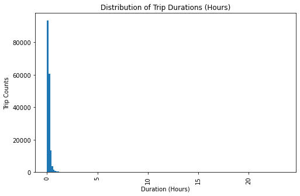

```python
# Create a histgram
binsize = 0.15
bins = np.arange(0, df_trips['duration_hrs'].max()+binsize, binsize)
plt.figure(figsize=[8, 5])
plt.hist(data=df_trips, x='duration_hrs', bins=bins)
plot_labels('Distribution of Trip Durations (Hours)', 'Duration (Hours)', 'Trip Counts')

plt.show()
```

```python
df_trips['duration_hrs'].nlargest(10)
```

```
85465     23.485556
127999    23.199722
112435    23.168611
5203      23.109722
95750     22.920000
8631      22.652500
107581    22.096667
90195     20.668889
86454     20.582500
123383    20.536111
Name: duration_hrs, dtype: float64
```

```python
df_trips['duration_hrs'].describe(percentiles=[.995])
```

```
count    174880.000000
mean          0.195562
std           0.456254
min           0.016944
50%           0.141667
99.5%         1.399949
max          23.485556
Name: duration_hrs, dtype: float64
```

It looks like 99.5% of trips is less than 1.4 hrs. The bins and ticks need to rearrnge to exclude the outliers

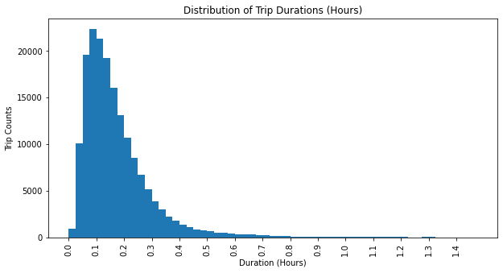

```python
# Create a histgram
bins = np.arange(0, 1.5, 0.025)
ticks = np.arange(0, 1.5, 0.1)
plt.figure(figsize=[10, 5])
plt.hist(data=df_trips, x='duration_hrs', bins=bins)
plt.xticks(np.round(ticks, 1), np.round(ticks, 1))
plot_labels('Distribution of Trip Durations (Hours)', 'Duration (Hours)', 'Trip Counts')

plt.show()
```

### Explore the Distribution of ages

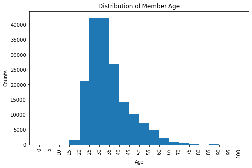

```python
# Create a histgram
plt.figure(figsize=[8, 5])
bins = np.arange(0, df_trips['member_age'].max()+5, 5)
plt.hist(data=df_trips, x='member_age', bins=bins)
plt.xticks(bins, bins)
plot_labels('Distribution of Member Age', 'Age', 'Counts')
```

### Explore the user types.

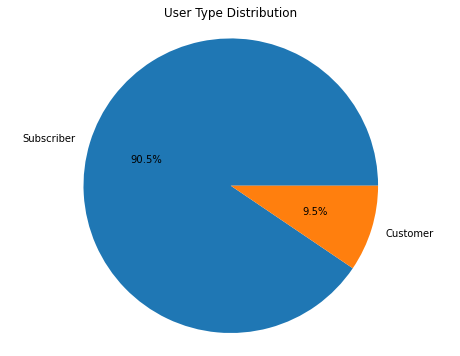

```python
user_type_counts = df_trips['user_type'].value_counts()
labels = user_type_counts.index
sizes = user_type_counts.values

# Create the pie chart
plt.figure(figsize=(8, 6))
plt.pie(sizes, labels=labels, autopct='%1.1f%%')
plt.axis('equal')
plt.title('User Type Distribution')
plt.show()
```

### Explore the gender distribution.

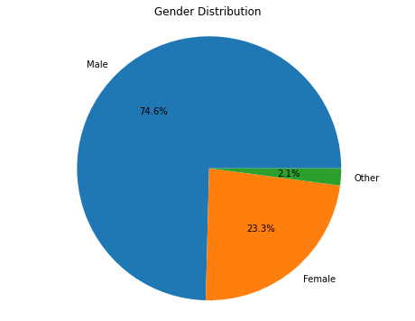

```python
gender_counts = df_trips['member_gender'].value_counts()
labels = gender_counts.index
sizes = gender_counts.values

# Create the pie chart
plt.figure(figsize=(8, 6))
plt.pie(sizes, labels=labels, autopct='%1.1f%%')
plt.axis('equal')
plt.title('Gender Distribution')
plt.show()
```

### Explore the top 5 popular start/end station

```python
top_5_start_stations = df_trips['start_station_name'].value_counts().head()
print(top_5_start_stations)
```

```
Market St at 10th St                                         3649
San Francisco Caltrain Station 2  (Townsend St at 4th St)    3406
Berry St at 4th St                                           2951
Montgomery St BART Station (Market St at 2nd St)             2711
Powell St BART Station (Market St at 4th St)                 2620
Name: start_station_name, dtype: int64
```

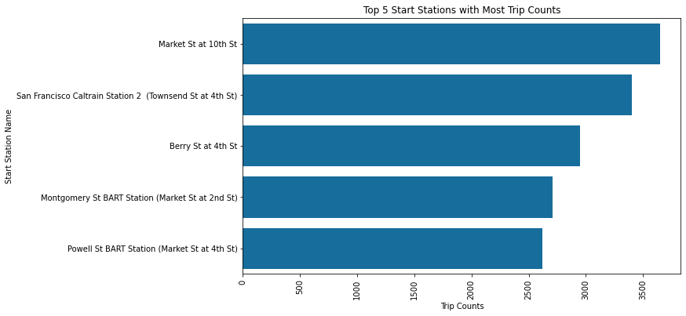

```python
# Create bar plot
plt.figure(figsize=(10, 6))
base_color = sb.color_palette('colorblind')[0]
sb.barplot(x=top_5_start_stations.values, y=top_5_start_stations.index, color=base_color)
plot_labels('Top 5 Start Stations with Most Trip Counts', 'Trip Counts', 'Start Station Name')
plt.show()
```

```python
top_5_end_stations = df_trips['end_station_name'].value_counts().head()
print(top_5_end_stations)
```

```
San Francisco Caltrain Station 2  (Townsend St at 4th St)    4622
Market St at 10th St                                         3709
Montgomery St BART Station (Market St at 2nd St)             3461
San Francisco Ferry Building (Harry Bridges Plaza)           3151
San Francisco Caltrain (Townsend St at 4th St)               2860
Name: end_station_name, dtype: int64
```

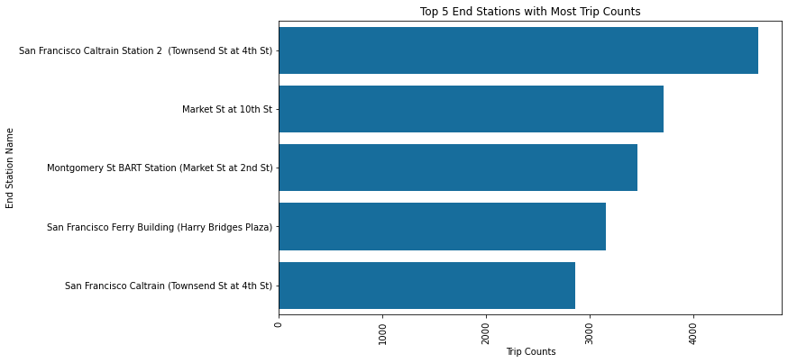

```python
# Create bar plot
plt.figure(figsize=(10, 6))
sb.barplot(x=top_5_end_stations.values, y=top_5_end_stations.index, color=base_color)
plot_labels('Top 5 End Stations with Most Trip Counts', 'Trip Counts', 'End Station Name')
plt.show()
```

### Explore the usage pattern in hours of a day

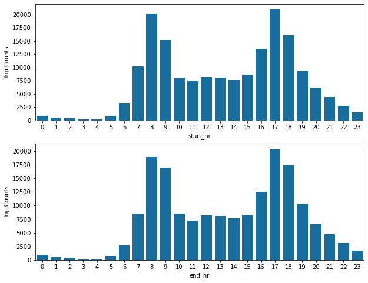

```python
fig, axes = plt.subplots(nrows=2, ncols=1, figsize=(10, 8))

# Create a bar plot for start_hr in the first subplot
sb.countplot(data=df_trips, x='start_hr', color=base_color, ax=axes[0])
axes[0].set_ylabel('Trip Counts')

# Create a bar plot for end_hr in the second subplot
sb.countplot(data=df_trips, x='end_hr', color=base_color, ax=axes[1])
axes[1].set_ylabel('Trip Counts')

plt.show()
```

### Explore the usage pattern in days of a week

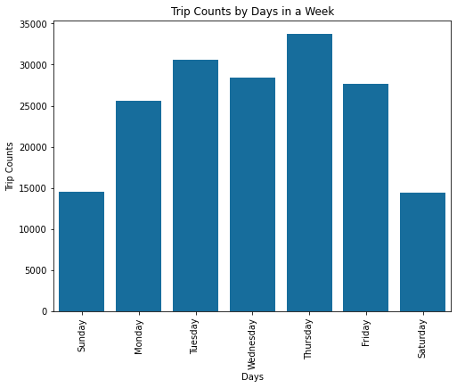

```python
# Create a bar plot for start_day
plt.figure(figsize=(8, 6))
sb.countplot(data=df_trips, x='start_day', color=base_color)
plot_labels('Trip Counts by Days in a Week', 'Days', 'Trip Counts')
plt.show()
```

### Discuss the distribution(s) of your variable(s) of interest. Were there any unusual points? Did you need to perform any transformations?

> In terms of time duration of the trips, almost 99% of them are short and fast trips, despite of the outliers > 20 hrs. Majority of the trips are between 0.1 hr - 0.2 hr (6 mins - 12 mins). In user components, 90% of the users are subscribers, 75% are male, and age range is between 25 and 40. From the top 5 start and end stations with most trip counts, Market St at 10th St, San Francisco Caltrain, and BART Station are the busiest and all at downtown area. The amount of trips reached its peak at 8 a.m. and 17 p.m. during the day, with business days (Mon-Fri) having more trips than weekends.

> There is no particular transformation for the dataset, but need to remind the outliers in `duration_hr`.

## Bivariate Exploration

> In this section, investigate relationships between pairs of variables in your data. Make sure the variables that you cover here have been introduced in some fashion in the previous section (univariate exploration).

```python
# State numeric variables
numeric_vars = ['start_hr', 'end_hr', 'duration_hrs', 'member_age']
```

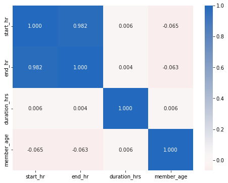

```python
# Create correlation matrix
plt.figure(figsize = [8, 6])
sb.heatmap(df_trips[numeric_vars].corr(), annot = True, fmt = '.3f',
           cmap = 'vlag_r', center = 0)
plt.show()
```

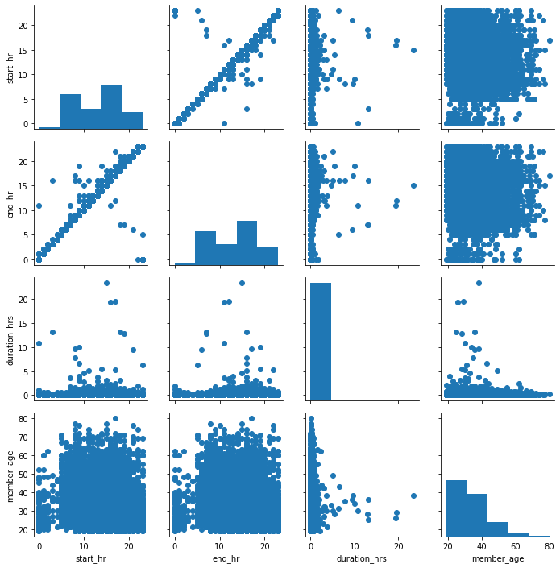

```python
# Select 10000 samples to create the plot matrix for all numeric variables
trip_samples = df_trips.sample(10000)
g = sb.PairGrid(data=trip_samples, vars=numeric_vars)
g = g.map_diag(plt.hist, bins=5)
g.map_offdiag(plt.scatter)
plt.show()
```

### Trip Duration by User Type

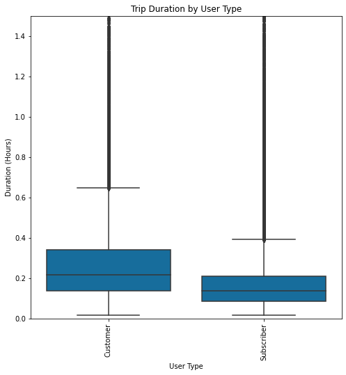

```python
# Create boxplots
plt.figure(figsize=(8, 8))
sb.boxplot(data=df_trips, x='user_type', y='duration_hrs', color=base_color)
plot_labels('Trip Duration by User Type', 'User Type', 'Duration (Hours)')
plt.ylim(0, 1.5)  # Set the limit for the time duration
plt.show()
```

It's interesting to see that customers tend to have longer trip than subscribers.

### Trip Counts by User Type and Hours of a Day:

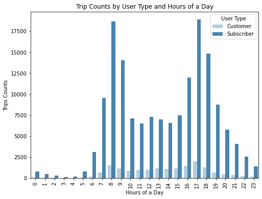

```python
# Create a clustered bar chart
plt.figure(figsize=(8, 6))
sb.countplot(data=df_trips, x='start_hr', hue='user_type', palette = 'Blues')
plot_labels('Trip Counts by User Type and Hours of a Day', 'Hours of a Day', 'Trips Counts')
plt.legend(title='User Type')
plt.show()
```

### Trip Counts by User Type and Day of Week:

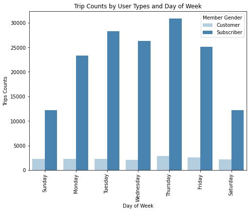

```python
# Create a clustered bar chart
plt.figure(figsize=(8, 6))
sb.countplot(data=df_trips, x='start_day', hue='user_type', palette = 'Blues')
plot_labels('Trip Counts by User Types and Day of Week', 'Day of Week', 'Trips Counts')
plt.legend(title='Member Gender')
plt.show()
```

From the two barplots above, subscriber usage obviously rises during typical rush hours at 8 a.m. and 5 p.m. during business days. But we cannot see the clear usage pattern from the customers, but similarly they use mostly on rush hours and Thursday.

### Talk about some of the relationships you observed in this part of the investigation. How did the feature(s) of interest vary with other features in the dataset?

> Since most of users like to have short trips, `start_hr` and `end_hr` have strong positive correlation. But other numeric variables do not have any strong relationship with each other. And we need to set the upper bound for the `duration_hrs`. The usage pattern between subscribers and customers are very different. Subscribers mostly rent the bikes for work commute purpose. There is no clear pattern for customers, they might use the bike for random or casual trips since they only accounted for 9.5% in user base.

## Multivariate Exploration

> Create plots of three or more variables to investigate your data even further. Make sure that your investigations are justified, and follow from your work in the previous sections.

### Agerage Trip Duration by Day of a Week and User Type

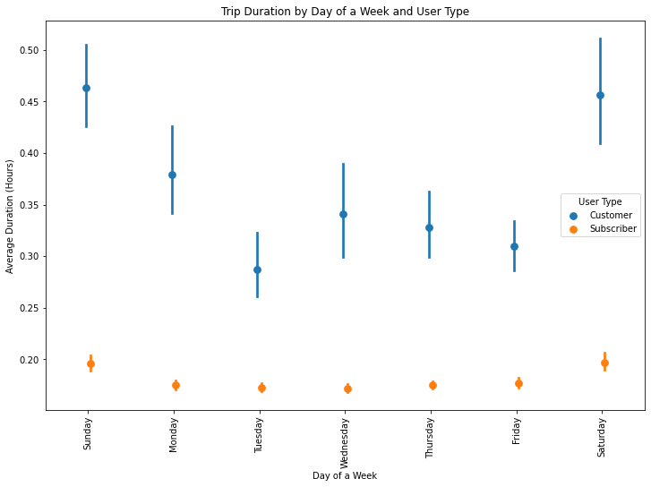

```python
# Create a pointplot
plt.figure(figsize=(12, 8))
sb.pointplot(data=df_trips, x='start_day', y='duration_hrs', hue='user_type', linestyles='', dodge=True)
plot_labels('Trip Duration by Day of a Week and User Type', 'Day of a Week', 'Average Duration (Hours)')
plt.legend(title='User Type')
plt.show()
```

Customers relatively have long trips regardless of what day of the week (longest on weekends), whereas subscribers typically have shorter trips, but with a slight rise on weekends but not to the same extent as customers.

### Trip Duration by User Type and Gender

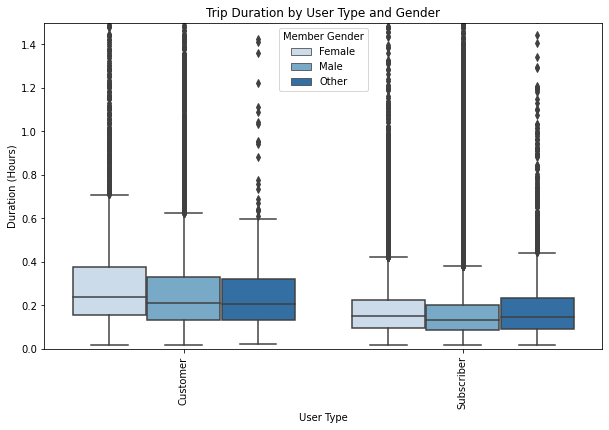

```python
# Create the boxplot
plt.figure(figsize=(10, 6))
sb.boxplot(data=df_trips, x='user_type', y='duration_hrs', palette = 'Blues', hue='member_gender')
plot_labels('Trip Duration by User Type and Gender', 'User Type', 'Duration (Hours)')
plt.ylim(0, 1.5)
plt.legend(title='Member Gender')
plt.show()
```

Among customers, female users tend to travel longer than male and other genders. On the other side, male subscriber group surprisingly have the narrowest trip duration range.

### Trip Counts by User Type, Gender, and Day of the Week

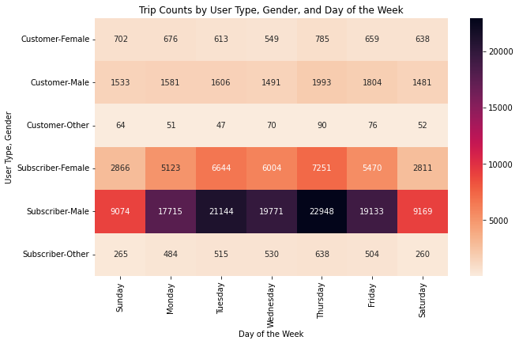

```python
# Group the data by user_type, member_gender, and start_day
grouped_data = df_trips.groupby(['user_type', 'member_gender', 'start_day']).size().reset_index(name='count')

# Pivot the data to create a matrix suitable for the heatmap
heatmap_data = grouped_data.pivot_table(index=['user_type', 'member_gender'], columns='start_day', values='count')

# Create the heatmap
plt.figure(figsize=(10, 6))
sb.heatmap(heatmap_data, annot=True, fmt='d', cmap='rocket_r')
plot_labels('Trip Counts by User Type, Gender, and Day of the Week', 'Day of the Week', 'User Type, Gender')
plt.show()
```

Majority of the trips were taken during the weekdays, and most trips were on Thursdays and Tuesdays, and there are a lot more subscriber usage than customers, and Male subscriber group had most trip counts.

### Talk about some of the relationships you observed in this part of the investigation. Were there features that strengthened each other in terms of looking at your feature(s) of interest?

> - The difference in trip duration between customers and subscribers becomes more evident when analyzed across different days of the week. Customers generally have longer trips regardless of the day, with the longest trips on weekends. Subscribers have shorter trips overall, but with a slight increase in trip duration on weekends.
> - The majority of trips are taken during the weekdays, with the highest counts on Thursdays and Tuesdays. Subscribers use the service more frequently than customers, and the male subscriber group has the highest trip counts.

### Were there any interesting or surprising interactions between features?

> The trip duration patterns across genders are more pronounced when considering user type. Among customers, female users tend to have longer trips than males and other genders. However, among subscribers, male users have the shortest trip duration range, which is an interesting observation.

## Conclusions

> - Trip durations were mostly short, with a majority of trips lasting less than an hour. The distribution was positively skewed, indicating that riders generally prefer short, quick trips.
> - Subscribers made up a significant portion of the user base. Males were the predominant gender among both user types. Customers tend to have longer trips than subscribers
> - The analysis of trip counts by day of the week revealed that the service was used more heavily during weekdays, with Thursdays and Tuesdays having the highest usage. This suggests that the service is popular among commuters for work-related trips.
> - The top five start and end stations were all located in downtown San Francisco, indicating that the service is particularly popular in areas with high foot traffic and convenient access to other modes of transportation.
> - Female customers having the longest trip durations on average. Among subscribers, male users had the shortest trip durations.